# ggplot_activity

Charles Hendrickson

8/18/2021

## Read in data

```r
space_launches <- read.csv(here("data", "space_launches.csv"))
```

# Task 1: Do your data viz worst

Just like it takes a lot of work to make a really wonderful graph, it takes effort to make a graph really awful. Put effort and creativity into this - you will learn a lot in the process if you do.

```r
sucky_plot <- ggplot(space_launches, aes(x = type, y = launch_year)) +
  geom_point(shape = 22,
             fill = "yellow",
             color = "purple",
             size = 4,
             alpha = 0.5) +
  theme(
    panel.grid = element_blank(),
    plot.background = element_rect(fill = "green"),
    axis.text.x = element_text(color = "brown"),
    axis.title = element_text(color = "purple", size = 15))+
  ggtitle("THIS GRAPH SUCKS", subtitle = "by Dr. I HAVE NO IDEA WHAT I'M DOING")
```

```r
ggsave(filename = here("figs", "sucky_plot.png"))
```

Task 2: Wrangling practice with the SF Greenhouse Gas data Download the San_Francisco_Communitywide_Greenhouse_Gas_Inventory.csv file (I’ll put this in Slack). Information about the data is available here.

Read in the SF emissions dataset, then complete the following:

```r
san_fran <- read.csv(here("data",
              "San_Francisco_Communitywide_Greenhouse_Gas_Inventory.csv"))
```

Create a summary table of total annual greenhouse gas emissions (only from Emissions_mtCO2e column) by sector_general

```r
emissions_total <- san_fran %>%
  group_by(Sector_General) %>%
  summarize(Emissions_mtCO2e_total = sum(Emissions_mtCO2e, na.rm = TRUE))
```

Create a summary table of total annual greenhouse gas emissions (only from Emissions_mtCO2e column) by year and commodity type

```r
emissions_total_2 <- san_fran %>%
  group_by(Calendar_Year, Commodity_Type) %>%
  summarize(Emissions_mtCO2e_total = sum(Emissions_mtCO2e, na.rm = TRUE))
```

Create a subset of the data that only contains observations from 2005 on, only for observations where Sector_Detail2 contains the pattern “PG&E”, then limit to columns Calendar_Year, Sector_Detail2 and Emissions_mtCO2e.

```r
subset <- san_fran %>%
  filter(Calendar_Year >= 2005)%>%
  filter(str_detect(Sector_Detail2, pattern = "PG&E")) %>%
  select(Calendar_Year, Sector_Detail2, Emissions_mtCO2e)
```

Task 3: Do your data viz best Create a finalized graph (as perfect as you can make it) using the San Francisco GHG emissions dataset. You get to choose what you want to visualize. You can pick which variables & observations you’re interested in. You may want to do some wrangling / summarizing first.

```r
sector_emissions_2005 <- san_fran %>%
  group_by(Sector_GPC_Detail, Calendar_Year) %>%
  summarize(Emissions_mtCO2e = sum(Emissions_mtCO2e)) %>%
  ungroup() %>%
  filter(Calendar_Year %in% c(2005)) %>%
  arrange(Emissions_mtCO2e) %>%
  mutate(Sector_GPC_Detail = fct_inorder(Sector_GPC_Detail) %>%
           fct_rev())
```

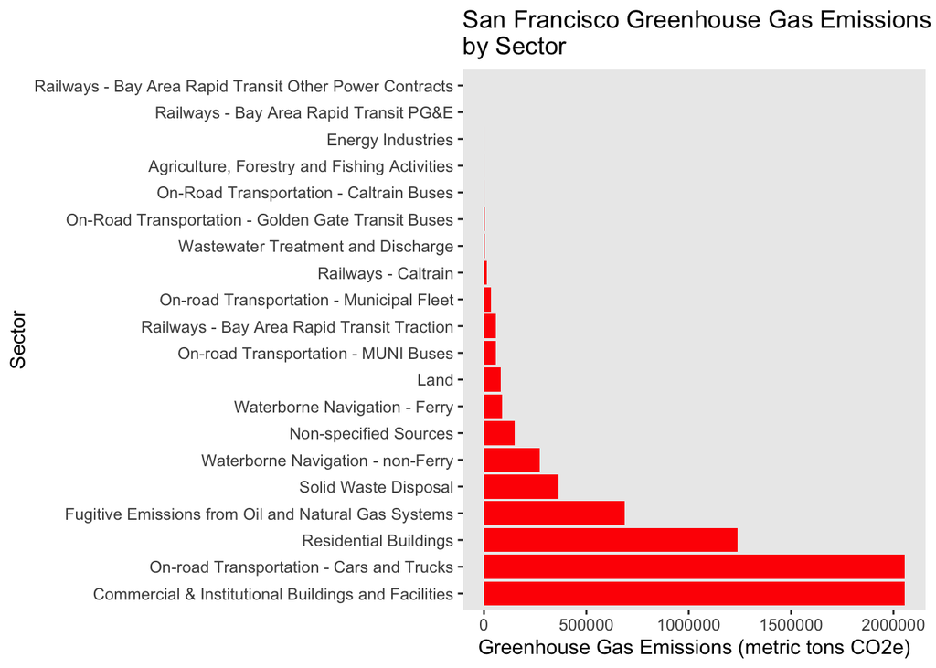

```r
ggplot(sector_emissions_2005, aes(y = Sector_GPC_Detail, x = Emissions_mtCO2e)) +
  geom_col(fill = "red")+
           theme(panel.grid = element_blank()) +
ggtitle("San Francisco Greenhouse Gas Emissions \nby Sector") +
  xlab("Greenhouse Gas Emissions (metric tons CO2e)") +
  ylab("Sector")
```

```r
ggsave(filename = here("figs", "SF_Gas_Emissions.png"))
```